# kitsPreview 導覽：dexter、immer、cNORM 的原貌

這份導覽讓你看 kitsPreview 印出來的樣子。 文字很少；重點是每一步的輸出、表和圖。

**資料是模擬資料。** 示範資料來自 kits 套件，沒有任何一列是真實的孩子。 請不要把這裡的數字當作 KIT 的結果引用。

## 0 kitsPreview 是什麼

**問題：kitsPreview 和 kits 有什麼不同？**

```r
library(kitsPreview)
library(dplyr)
library(purrr)
```

## 1 資料

**問題：kitsPreview 要什麼樣的作答資料？**

示範資料放在 kits 裡。 這裡只從 kits 取資料，不用 `library(kits)`。

```r
data("kitm03", "kitm36", package = "kits")
kitm03$responses |>
  head(3)
```

```
#> # A tibble: 3 × 9
#>   visit_id        subj_id cohort sex   wave_m age_m item_id item_score domain
#>   <chr>           <chr>   <chr>  <chr>  <dbl> <dbl> <chr>        <int> <chr>
#> 1 M03_c55df9b_M03 c55df9b M03    girl       3  3.06 lana01           1 lan
#> 2 M03_c55df9b_M03 c55df9b M03    girl       3  3.06 lana02           0 lan
#> 3 M03_c55df9b_M03 c55df9b M03    girl       3  3.06 lana03           0 lan
```

kitsPreview 沒有 `kits_resp()`。 它直接收 dexter 的格式：作答矩陣，或有 `visit_id`、`item_id`、`item_score` 的長表。 留下兩個世代的語言。

```r
lan03 <- kitm03$responses |>
  filter(domain == "lan")
lan36 <- kitm36$responses |>
  filter(domain == "lan")
```

孩子的資料另外放一張表，一個人次一列。 計分時用 `persons =` 接上。

```r
persons <- rbind(kitm03$responses, kitm36$responses) |>
  distinct(visit_id, subj_id, cohort, sex, wave_m, age_m)
persons |>
  count(cohort)
```

```
#> # A tibble: 2 × 2
#>   cohort     n
#>   <chr>  <int>
#> 1 M03     4006
#> 2 M36     1885
```

## 2 校準

**問題：每一題的每個步驟落在量尺的哪裡？**

預設的引擎是 dexter（`fit_enorm()`，條件最大概似）。

```r
item <- kits_item(lan03)
item
```

```
#> <kits_item> PCM (dexter, CML): 4004 person-waves, 24 items, 72 steps, 20 item pattern(s)
#>  item_id item_score  beta beta_se   thr thr_se
#>   lana01          1 -4.45    0.11 -4.91   0.08
#>   lana01          2 -3.98    0.11 -4.14   0.06
#>   lana01          3 -4.19    0.09 -3.55   0.06
#>   lana02          1 -4.72    0.10 -4.89   0.08
#>   lana02          2 -3.08    0.09 -3.33   0.06
#>   lana02          3 -2.81    0.08 -2.38   0.06
#> ... (all steps: coef(x) or x$thresholds)
#> Item fit: 1 of 24 items outside 0.6-1.4 (1 underfit, 0 overfit: lanc01); see x$itemfit, plot(x, type = "fit").
```

印出來的第一行說明引擎、人次、題數、步驟數和作答組合數。 最後一行是題目適配的摘要（第 3 節）。 全部的步驟用 `coef()` 取。

```r
coef(item) |>
  filter(item_score == 1) |>
  head(4)
```

```
#>   item_id item_score  beta beta_se   thr thr_se
#> 1  lana01          1 -4.45    0.11 -4.91   0.08
#> 2  lana02          1 -4.72    0.10 -4.89   0.08
#> 3  lana03          1 -2.34    0.11 -3.28   0.06
#> 4  lana04          1 -2.22    0.10 -2.90   0.06
```

### Wright 圖

kitsPreview 的 Wright 圖畫在 `kits()` 的結果上：`kits()` 一次做完校準和計分。 這是互動圖；滑鼠停在點上可以看題號。

```r
fit <- kits(lan03)
plot(fit)
```

[interactive chart not shown]

### dexter 自己的輸出

`summary()` 先印整理過的表，再印 dexter 自己的輸出。

```r
summary(item)
```

```
#> <kits_item> PCM (dexter, CML): 4004 person-waves, 24 items, 72 steps, 20 item pattern(s)
#>  item_id item_score  beta beta_se   thr thr_se
#>   lana01          1 -4.45    0.11 -4.91   0.08
#>   lana01          2 -3.98    0.11 -4.14   0.06
#>   lana01          3 -4.19    0.09 -3.55   0.06
#>   lana02          1 -4.72    0.10 -4.89   0.08
#>   lana02          2 -3.08    0.09 -3.33   0.06
#>   lana02          3 -2.81    0.08 -2.38   0.06
#> ... (all steps: coef(x) or x$thresholds)
#> Item fit: 1 of 24 items outside 0.6-1.4 (1 underfit, 0 overfit: lanc01); see x$itemfit, plot(x, type = "fit").
#>
#> ---- Original output: dexter::fit_enorm() ----
#> ℹ Parameters for the Extended Nominal Response Model
#>
#> Method: CML, converged in 105 iterations
#> items: 24
#> responses: 42790
#>
#> Use `coef()` (`?dexter::coef.enorm()`) to extract the item parameters.
#>
#> ---- End of the original output (kits_original(x) returns the object) ----
```

dexter 的物件用 `kits_original()` 取，再用 dexter 自己的函數讀。

```r
enorm <- kits_original(item)
class(enorm)
```

```
#> [1] "enorm" "list"
```

```r
coef(enorm) |>
  head(3)
```

```
#>   item_id item_score      beta    SE_beta
#> 1  lana01          1 -4.450859 0.10843668
#> 2  lana01          2 -3.978905 0.10976589
#> 3  lana01          3 -4.193151 0.08891508
```

dexter 的表叫 `SE_beta`；kitsPreview 把它改成 `beta_se`。

### 換一個引擎：immer

同一個模型，改用 immer 的 `immer_cml()` 估計。

```r
item_immer <- kits_item(lan03, engine = "immer")
item_immer
```

```
#> <kits_item> PCM (immer, CML): 4004 person-waves, 24 items, 72 steps, 20 item pattern(s)
#>  item_id item_score  beta beta_se   thr thr_se
#>   lana01          1 -4.45    0.11 -4.91   0.08
#>   lana01          2 -3.98    0.11 -4.14   0.06
#>   lana01          3 -4.19    0.09 -3.55   0.06
#>   lana02          1 -4.72    0.10 -4.89   0.08
#>   lana02          2 -3.08    0.09 -3.32   0.06
#>   lana02          3 -2.81    0.08 -2.38   0.06
#> ... (all steps: coef(x) or x$thresholds)
#> Item fit: 1 of 24 items outside 0.6-1.4 (1 underfit, 0 overfit: lanc01); see x$itemfit, plot(x, type = "fit").
```

immer 自己的物件也留著。 immer 的參數是累加的，名稱是「題號_Cat 類別」。

```r
kits_original(item_immer)$b |>
  head(4)
```

```
#> lana01_Cat1 lana01_Cat2 lana01_Cat3 lana02_Cat1
#>   -4.355003   -8.238635  -12.335816   -4.621607
```

immer 的原點和 dexter 不同；kitsPreview 減掉一個常數，放到 dexter 的原點。 這裡減掉的是 0.095。 兩個引擎的差距：

```r
c("beta", "beta_se", "thr", "thr_se") |>
  map(\(v) tibble(
    column = v,
    max_abs_diff = max(abs(coef(item_immer)[[v]] - coef(item)[[v]]))
  )) |>
  list_rbind()
```

```
#> # A tibble: 4 × 2
#>   column  max_abs_diff
#>   <chr>          <dbl>
#> 1 beta         0.0168
#> 2 beta_se      0.00119
#> 3 thr          0.00944
#> 4 thr_se       0.00151
```

## 3 題目適配

**問題：每一題的作答符合模型嗎？**

`kits_item()` 已經在同一份資料上算好題目適配，存在 `item$itemfit`。 依 infit 由大到小排。

```r
item$itemfit |>
  arrange(desc(infit)) |>
  head(5)
```

```
#>   item_id    n pvalue  rir infit outfit flag
#> 1  lanb05 1693   0.95 0.45  0.94   0.92   ok
#> 2  lanc02 3460   0.68 0.44  0.93   1.09   ok
#> 3  lanb06 1692   0.77 0.66  0.92   0.87   ok
#> 4  lanc09 3054   0.31 0.54  0.92   0.93   ok
#> 5  lanb04 1691   0.87 0.61  0.91   0.83   ok
```

圖上每題兩個點；灰色帶是印出結果時用的範圍。

```r
plot(item, type = "fit")
```

[interactive chart not shown]

範圍外的題有 1 題：lanc01。 `kits_itemfit(data, item)` 給同一張表；它用來拿同一批題目檢查別的資料。

```r
identical(kits_itemfit(lan03, item), item$itemfit)
```

```
#> [1] TRUE
```

dexter 自己也有題目的圖：每組能力的平均得分（點）和模型的預測（灰線）。 它畫在 dexter 的物件上，資料要用 dexter 的長表，人次的欄叫 dexter 的名字 `person_id`。 左邊是範圍外的 lanc01，右邊是一題適配好的題目。

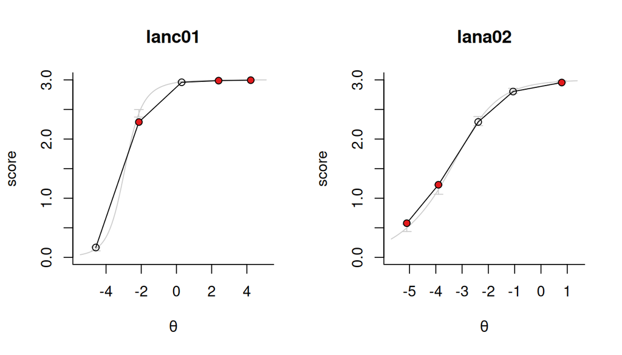

```r
dexter_long <- lan03 |>
  select(person_id = visit_id, item_id, item_score)
par(mfrow = c(1, 2))
plot(kits_original(item), item_id = c(outside$item_id[1], "lana02"), dataSrc = dexter_long)
```

## 4 計分

**問題：每個人次在量尺的哪裡？**

計分一律用 dexter 的 `ability()`（WLE）。 `persons =` 把孩子的資料接在後面。

```r
scores <- kits_subj(lan03, item, persons = persons)
scores |>
  select(pattern_id, visit_id, raw, raw_max, theta, se, infit, outfit, flag, wave_m) |>
  head(4)
```

```
#> <kits_subj> 4 person-waves; WLE (dexter)
#>          visit_id wave_m theta   se   flag
#> 1 M03_c55df9b_M03      3 -4.54 0.68     ok
#> 2 M03_c55df9b_M06      6 -5.07 0.89     ok
#> 3 M03_c55df9b_M12     12 -2.75 0.38     ok
#> 4 M03_c55df9b_M18     18 -1.68 0.41 misfit
#> Other columns: pattern_id, raw, raw_max, infit, outfit
#> Next: kits_norms(x), kits_norm_z(x, norm), kits_subj_table(x), kits_vertical(x), summary(x).
```

```r
scores |>
  count(flag)
```

```
#> <kits_subj> 4 person-waves; WLE (dexter)
#>      flag    n
#> 1  misfit  285
#> 2      ok 3510
#> 3 perfect   74
#> 4    zero  135
```

`summary()` 先印摘要，再印 dexter 自己的 `ability()` 表。 dexter 自己的輸出刻意保留 dexter 的欄名（`person_id`、`booklet_id`、`booklet_score`），其他地方都用 kitsPreview 的名字。

```r
summary(scores)
```

```
#> <kits_subj> WLE (dexter): 4004 person-waves
#>      theta                se             infit             outfit
#>  Min.   :-6.18482   Min.   :0.2942   Min.   :0.03263   Min.   : 0.02725
#>  1st Qu.:-2.88427   1st Qu.:0.3811   1st Qu.:0.50053   1st Qu.: 0.30721
#>  Median : 0.31943   Median :0.4144   Median :0.73232   Median : 0.56963
#>  Mean   :-0.01288   Mean   :0.5485   Mean   :0.81006   Mean   : 0.89632
#>  3rd Qu.: 2.98175   3rd Qu.:0.5855   3rd Qu.:1.05139   3rd Qu.: 0.98208
#>  Max.   : 6.02378   Max.   :1.7988   Max.   :2.89426   Max.   :76.76057
#>                                      NA's   :209       NA's   :209
#> flag
#>  misfit      ok perfect    zero
#>     285    3510      74     135
#>
#> ---- Original output: dexter::ability() (first rows) ----
#>   booklet_id       person_id booklet_score      theta        se
#> 1       bk01 M03_011e336_M03             2 -4.5449751 0.6842516
#> 2       bk02 M03_011e336_M06             1 -5.0674710 0.8891538
#> 3       bk03 M03_011e336_M12             6 -3.4952570 0.4449515
#> 4       bk03 M03_011e336_M18            16 -2.0251861 0.4029727
#> 5       bk04 M03_011e336_M36            29  1.0038433 0.3081806
#> 6       bk04 M03_011e336_M48            28  0.9115902 0.3043659
#> ---- End of the original output (kits_original(x) returns the object) ----
```

### 原始分對照表

每個波次的標準題本，每個原始分對應一個 θ。

```r
raw_table <- kits_subj_table(scores)
raw_table |>
  filter(wave_m == 12) |>
  head(5)
```

```
#>   wave_m form n_items raw theta   se n  pct cum_pct wave_n form_pct
#> 1     12    1      15   0 -6.20 1.76 0 0.00    0.00    447    98.66
#> 2     12    1      15   1 -5.08 0.89 0 0.00    0.00    447    98.66
#> 3     12    1      15   2 -4.58 0.68 5 1.13    1.13    447    98.66
#> 4     12    1      15   3 -4.23 0.58 6 1.36    2.49    447    98.66
#> 5     12    1      15   4 -3.94 0.52 4 0.91    3.40    447    98.66
```

`form_pct` 是答標準題本的孩子占這一波的百分比。 其他作答組合的孩子不在表裡。

## 5 連結

**問題：M36 和 M03 的孩子怎麼放上同一把量尺？**

### M36 → M03

M36 自己校準一次，再用共同題的門檻連結。

```r
item36 <- kits_item(lan36)
co <- kits_linking(item36, item)
co
```

```
#> <kits_link> new value = intercept + slope x old value
#>   intercept = 2.46
#>   slope     = 0.94
#>   points from: every common item step
#>   points: 54 (items: 18); dropped: 4 (lanc01:1, lanc01:2, lanc01:3, lanc04:1)
#>   before screening: intercept 2.53, slope 1.04; screening: |e| > 2 SD(e)
#> Next: plot(x), coef(x), kits_code(x); scores: s$theta <- x$intercept + x$slope * s$theta.
```

```r
coef(co)
```

```
#> intercept     slope
#> 2.4588844 0.9388172
```

```r
plot(co)
```

[interactive chart not shown]

kitsPreview 沒有 `kits_convert()`；換尺就是這條直線，SE 乘上斜率。

```r
scores36 <- kits_subj(lan36, item36, persons = persons) |>
  mutate(theta = co$intercept + co$slope * theta, se = co$slope * se)
both <- rbind(scores, scores36)
```

`kits_vertical()` 摘要每個世代、每個波次的位置。

```r
v <- kits_vertical(both)
v
```

```
#> <kits_vertical> 15 cohort x wave group(s)
#>  cohort wave_m   n age_med  mean   sd median   P25   P75
#>     M03      3 434    3.02 -4.95 0.78  -5.04 -5.04 -4.54
#>     M03      6 441    5.98 -4.33 0.77  -4.21 -4.57 -3.68
#>     M03     12 447   12.09 -2.45 0.78  -2.48 -3.02 -2.03
#>     M03     18 461   18.12 -1.06 0.95  -0.98 -1.68 -0.50
#>     M03     24 456   24.09  0.42 1.31   0.33 -0.50  1.37
#>     M03     36 433   35.94  1.77 1.02   1.75  1.10  2.41
#>     M03     48 439   47.86  2.63 1.06   2.69  1.87  3.29
#>     M03     60 449   60.24  3.56 1.04   3.65  2.98  4.12
#>     M03     72 444   72.00  4.22 0.94   4.12  3.46  4.95
#>     M36     36 284   35.85  1.73 1.07   1.66  1.06  2.39
#>     M36     48 260   48.17  2.60 1.04   2.66  1.89  3.25
#>     M36     60 242   60.18  3.44 1.10   3.42  2.80  4.36
#>     M36     72 243   72.03  4.06 0.97   4.10  3.42  4.45
#>     M36     84 441   86.56  4.59 1.23   4.54  3.79  5.30
#>     M36     96 415   97.94  5.17 1.20   5.20  4.45  5.90
```

```r
plot(v, type = "median")
```

[interactive chart not shown]

兩個世代都有的波次，兩組點應該很接近。

### 語言和動作接到 D

每個領域各校準一次，再用 `kitm03$anchors` 的錨題一起接到 D。

```r
domains <- c("lan", "motor") |>
  set_names()
resp_d <- domains |>
  map(\(d) filter(kitm03$responses, domain == d))
items_d <- resp_d |>
  map(kits_item)
```

kitsPreview 接到 D 用另一個函數 `kits_linking_d()`。

```r
d_link <- kits_linking_d(items_d, kitm03$anchors)
d_link
```

```
#> <kits_link> new value = intercept + slope x old value
#>   intercept = 64.44
#>   slope     = 7.17
#>   points from: the pass step of each anchor item (score >= 1)
#>   points: 27 (items: 27); dropped: 3 (bodyag10, bodybg01, bodybg04)
#>   before screening: intercept 63.48, slope 7.04; screening: |e| > 2 SD(e)
#>   kept points by domain: motor 22 (92%), lan 2 (8%)
#>   domain check: one slope shared by the domains, fitted with domain intercepts (kept points);
#>   it is not the slope of the line above:
#>  domain  n intercept slope
#>     lan  2     65.28  7.16
#>   motor 22     64.35  7.16
#> Next: plot(x), coef(x), kits_code(x); scores: s$theta <- x$intercept + x$slope * s$theta.
```

兩個領域共用一條線：D = 64.4 + 7.17 × θ。 `domains` 表讓每個領域有自己的截距，用來檢查共用一條線是否合理。

```r
plot(d_link)
```

[interactive chart not shown]

兩個領域的分數換成 D，再看每個波次的平均。

```r
d_scores <- map2(resp_d, items_d, \(r, i) kits_subj(r, i, persons = persons)) |>
  list_rbind(names_to = "domain") |>
  mutate(theta = d_link$intercept + d_link$slope * theta)
d_scores |>
  summarise(D = round(mean(theta), 1), .by = c(wave_m, domain)) |>
  tidyr::pivot_wider(names_from = domain, values_from = D)
```

```
#> # A tibble: 9 × 3
#>   wave_m   lan motor
#>    <dbl> <dbl> <dbl>
#> 1      3  29    20
#> 2      6  33.4  34.8
#> 3     12  46.9  54.1
#> 4     18  56.8  65.6
#> 5     24  67.5  72.8
#> 6     36  77.1  79.9
#> 7     48  83.3  86.3
#> 8     60  90    94
#> 9     72  94.7  98.3
```

## 6 常模

**問題：一個孩子在同月齡孩子中排在哪裡？**

常模用 cNORM 的 shash 模型。 先排除拿到最低分的孩子太多的波次。

```r
screen <- kits_norm_screen(scores)
screen
```

```
#> <kits_norm_screen> waves with 20% or more at the lowest score are left out
#>  cohort wave_m   n floor_pct normed
#>     M03      3 434     23.00  FALSE
#>     M03      6 441      7.90   TRUE
#>     M03     12 447      1.10   TRUE
#>     M03     18 461      0.20   TRUE
#>     M03     24 456      0.20   TRUE
#>     M03     36 433      0.20   TRUE
#>     M03     48 439      0.20   TRUE
#>     M03     60 449      0.20   TRUE
#>     M03     72 444      0.20   TRUE
#> Person-waves in the norms: 3570 of 4004 (use $normed)
```

男孩、女孩各配一份常模。

```r
normed <- scores[screen$normed, ]
norms <- kits_norms(normed, by = "sex")
norms |>
  filter(age_m %in% c(12, 24, 48)) |>
  select(sex, age_m, mu, sigma, P3, P50, P97)
```

```
#> <kits_norms> cNORM shash
#>    sex age_m    mu sigma    P3   P50   P97
#> 1  boy    12 -2.48  0.63 -4.08 -2.48 -0.92
#> 2  boy    24  0.04  0.95 -1.89  0.17  2.67
#> 3  boy    48  2.69  1.09  0.65  2.71  4.81
#> 4 girl    12 -2.41  0.72 -4.32 -2.51 -1.02
#> 5 girl    24  0.23  0.89 -1.72  0.28  2.44
#> 6 girl    48  2.59  0.93  0.76  2.66  4.78
#> Next: kits_norm_z(scores, x), plot(x), plot(x, scores = scores), kits_original(x).
```

```r
plot(norms, scores = normed)
```

[interactive chart not shown]

灰點是一個一個的孩子。 同齡 z 和百分等級加在分數表後面。

```r
scores_z <- kits_norm_z(scores, norms)
scores_z |>
  filter(!is.na(z)) |>
  summarise(mean = round(mean(z), 2), sd = round(sd(z), 2), .by = wave_m)
```

```
#>   wave_m  mean   sd
#> 1      6 -0.03 1.01
#> 2     12  0.06 0.96
#> 3     18 -0.14 0.96
#> 4     24  0.12 1.14
#> 5     36  0.02 0.87
#> 6     48 -0.06 0.98
#> 7     60  0.04 1.07
#> 8     72 -0.01 0.97
```

`kits_original()` 在常模上回傳 cNORM 自己的配適結果（`cnorm.shash()`）。 分組的常模每組一個；裡面只有係數和摘要，沒有孩子的分數。

```r
orig <- kits_original(norms)
names(orig)
```

```
#> [1] "boy"  "girl"
```

```r
orig$boy[c("mu_degree", "sigma_degree", "epsilon_degree", "delta_degree")] |>
  unlist()
```

```
#>      mu_degree   sigma_degree epsilon_degree   delta_degree
#>              5              4              3              2
```

整段 cNORM 程式在 `kits_code()` 裡（第 7 節）。

## 7 程式和公式

**問題：每一步背後是哪幾行程式、哪個公式？**

`kits_code()` 寫出可以直接執行的程式，不需要 kitsPreview。 校準的程式，核心是 dexter 的幾行：

```r
code_item <- kits_code(item)
code_item |>
  as.character() |>
  head(20) |>
  writeLines()
```

```
#> # Generated by kitsPreview 0.24.1: kits_item() with dexter and base R
#> # Needs: X, the response matrix given to kits_item()
#> # The names follow kits_equations().
#>
#> library(dexter)
#>
#> # Items nobody answered are not calibrated
#> X <- X[, colSums(!is.na(X)) > 0, drop = FALSE]
#>
#> # PCM: P(X = k | theta) = exp(k theta - sum_{g <= k} beta_g) / sum_h exp(h theta - sum_{g <= h} beta_g)
#> pcm <- function(theta, beta) {
#>   eta <- c(0, cumsum(theta - beta))
#>   exp(eta - max(eta)) / sum(exp(eta - max(eta)))
#> }
#>
#> # 1 Calibration: PCM by CML (dexter)
#> fit <- fit_enorm(X)
#> cf <- coef(fit)
#> V <- fit$est$acov.beta
```

照組的常模要一組一組寫。 cNORM 的部分：

```r
code_norm <- kits_code(attr(norms, "groups")[[1]]) |>
  as.character()
start <- grep("^# 2 Fit", code_norm)
writeLines(code_norm[start + 0:5])
```

```
#> # 2 Fit with each start of delta and keep the largest likelihood (cNORM shash).
#> #   As in kits_norms(), only cNORM's warnings of the kept fit are shown: a start that is not kept
#> #   (often a broken local solution) can warn, for example "Hessian is not positive definite".
#> fit_one <- function(d0) {
#>   warns <- character()
#>   fit <- withCallingHandlers(
```

這份程式可以直接執行。 女孩那一組寫到檔案，再在一個新的環境裡跑；程式要的 `D`、`age_m` 先放進去。

```r
girls <- normed |>
  filter(sex == "girl")
code_file <- tempfile(fileext = ".R")
kits_code(attr(norms, "groups")[[2]], file = code_file)
run <- list2env(list(D = girls$theta, age_m = girls$age_m))
sys.source(code_file, envir = run)
```

跑出來的百分位和 `kits_norms()` 的相同：

```r
girl_norm <- norms |>
  filter(sex == "girl")
max(abs(run$norm$P50 - girl_norm$P50))
```

```
#> [1] 0
```

`run$best` 是 cNORM 自己的物件，可以用 cNORM 自己的圖。 橫軸是月齡的平方根，因為 kitsPreview 用 `age_x = sqrt` 配常模。

```r
class(run$best)
```

```
#> [1] "cnormShash"
```

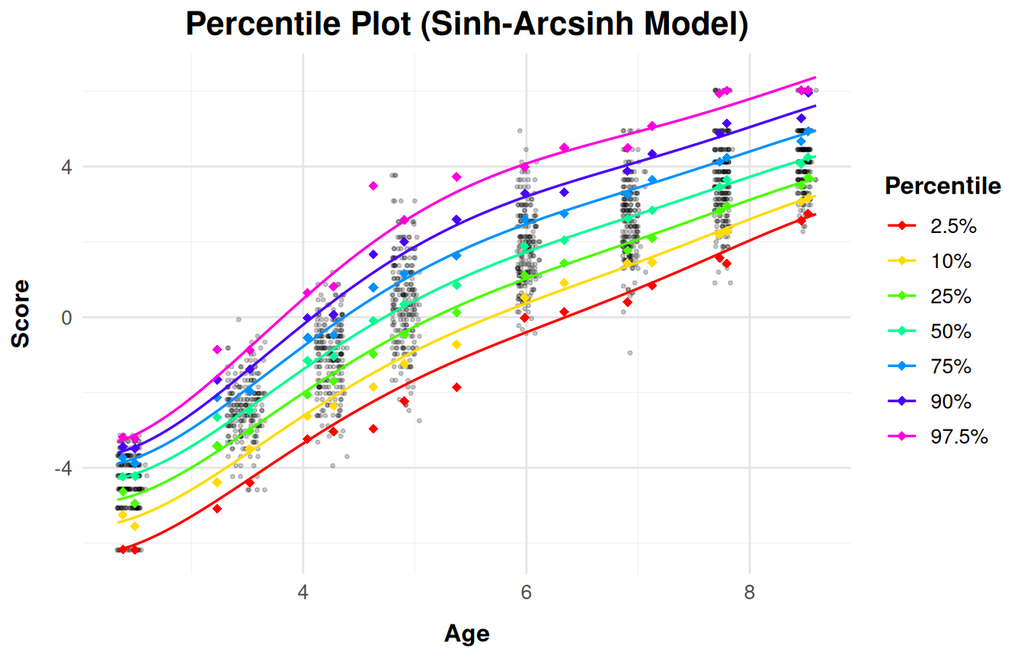

```r
plot(run$best, age = run$age_x(run$age_use), score = run$D_use)
```

`kits_equations()` 寫出公式；連結會附上這條線的數字。

```r
kits_equations(co)
```

```
#> mean/sigma line with one round of screening [Marco, 1977; Kolen & Brennan, 2014; GSED D-score: Weber et al., 2019]:
#>   A = SD(to) / SD(from),  B = mean(to) − A mean(from)
#>       (A = slope, B = intercept (intercept and slope are B and A of Kolen & Brennan, 2014); first with all points (intercept0, slope0))
#>   e_j = to_j − (B0 + A0 from_j);  drop j if |e_j| > cut SD(e)
#>       (then the intercept and slope again with the kept points)
#>   linking error = SD of the intercept (and of the slope) over R resamples of whole items
#>       (the screening is redone in every resample)
#>   cohort link: from, to = thr_ik (every common step);  D link: from = thr_is (pass step s, default 1), to = τ_i, the GSED difficulty (column tau)
#>
#> Shared slope A_s with domain intercepts B_d (the domains table) [this package]:
#>   A_s = √( Σ (to − mean_d(to))² / Σ (from − mean_d(from))² ),  B_d = mean_d(to) − A_s mean_d(from)
#>       (kept points; d = domain; columns slope and intercept of the domains table)
#>
#> This link (new = intercept + slope x old):
#>   new = 2.46 + 0.94 × old
#>       (54 points, 4 dropped)
#>
#> References:
#>   Marco, G. L. (1977). Item characteristic curve solutions to three intractable testing problems. Journal of Educational Measurement, 14(2), 139-160. doi:10.1111/j.1745-3984.1977.tb00033.x
#>   Kolen, M. J., & Brennan, R. L. (2014). Test equating, scaling, and linking (3rd ed.). Springer. doi:10.1007/978-1-4939-0317-7
#>   Weber, A. M., Rubio-Codina, M., Walker, S. P., van Buuren, S., Eekhout, I., et al. (2019). The D-score: a metric for interpreting the early development of infants and toddlers across global settings. BMJ Global Health, 4(6), e001724. doi:10.1136/bmjgh-2019-001724
```

主題也可以直接給，例如計分：

```r
kits_equations("subj")
```

```
#> Person ability: WLE [Warm, 1989; Firth, 1993; dexter: Maris et al., 2026]:
#>   θ̂_p = argmax_θ [ log L_p(θ) + ½ log I_p(θ) ]
#>       (the same as the posterior mode under the Jeffreys prior)
#>   L_p(θ) = Π_i P(X_pi = x_pi | θ),  I_p(θ) = Σ_i [Σ_k k² P_ik − (Σ_k k P_ik)²]
#>       (sums over the items person p answered)
#>   SE(θ̂_p) = √(I + (I′ / 2I)²) / I
#>       (I and its derivative I' at theta-hat)
#>
#> Linear conversions (each link: new = intercept + slope x old) [Kolen & Brennan, 2014]:
#>   θ* = B + A θ,  SE* = A SE
#>       (cohort link to the reference scale, then the D link; B = intercept, A = slope (intercept and slope are B and A of Kolen & Brennan, 2014))
#>
#> References:
#>   Warm, T. A. (1989). Weighted likelihood estimation of ability in item response theory. Psychometrika, 54(3), 427-450. doi:10.1007/BF02294627
#>   Firth, D. (1993). Bias reduction of maximum likelihood estimates. Biometrika, 80(1), 27-38. doi:10.1093/biomet/80.1.27
#>   Maris, G., Bechger, T., Koops, J., & Partchev, I. (2026). dexter: Data management and analysis of tests (R package version 1.8.1). https://dexter-psychometrics.github.io/dexter/
#>   Kolen, M. J., & Brennan, R. L. (2014). Test equating, scaling, and linking (3rd ed.). Springer. doi:10.1007/978-1-4939-0317-7
```

**問題：kitsPreview 和 kits 算出來一樣嗎？**

用 kits 重做校準、計分、連結和題目適配。

```r
k_resp <- kits::kits_resp(lan03)
k_item <- kits::kits_item(k_resp, scale = "lan M03")
k_subj <- kits::kits_subj(k_resp, k_item)
k_item36 <- kits::kits_item(kits::kits_resp(lan36), scale = "lan M36")
k_co <- kits::kits_linking(k_item36, k_item)
```

```r
tibble(
  result = c("thr", "theta", "intercept", "slope", "infit"),
  max_abs_diff = c(max(abs(coef(k_item)$thr - coef(item)$thr)),
                   max(abs(k_subj$theta - scores$theta)),
                   abs(k_co$intercept - co$intercept),
                   abs(k_co$slope - co$slope),
                   max(abs(k_item$itemfit$infit - item$itemfit$infit)))
)
```

```
#> # A tibble: 5 × 2
#>   result    max_abs_diff
#>   <chr>            <dbl>
#> 1 thr           5.68e-14
#> 2 theta         1.37e-13
#> 3 intercept     7.55e-15
#> 4 slope         1.11e-14
#> 5 infit         2.91e- 1
```

```r
k_co
```

```
#> <kits_link> new value = intercept + slope x old value
#>   scales: lan M36 -> lan M03
#>   intercept = 2.46
#>   slope     = 0.94
#>   points from: every common item step
#>   points: 54 (items: 18); dropped: 4 (lanc01:1, lanc01:2, lanc01:3, lanc04:1)
#>   before screening: intercept 2.53, slope 1.04; screening: |e| > 2 SD(e)
#> Next: kits_convert(scores, x), plot(x), summary(x, theta = ), confint(x).
#> Checks: OK
```

## 9 下一步

- **kits 入門**：`tutorial_beginner/`。同樣的步驟，用主套件 kits 一步一步做。
- **和 TAM 比較**：`tutorial_compare/`。
- **三個引擎**：`vignette("engines", package = "kitsPreview")` 比較 dexter、immer 和成對的 CCML。
- **完整流程**：`vignette("kits-flow", package = "kitsPreview")` 包括偏移、DIF、題目表和成長階梯。